# Risk Factor Analysis

## Outcome Variable

**Outcome Variable:** pers_wast

## Predictor Variables

**Intervention Variable:** feducyrs

**Adjustment Set:**

- arm
- W_mage
- meducyrs
- W_mhtcm
- W_mwtkg
- W_mbmi
- W_gagebrth
- W_birthwt
- W_birthlen
- single
- delta_W_mage
- delta_meducyrs
- delta_W_mhtcm
- delta_W_mwtkg
- delta_W_mbmi
- delta_W_gagebrth
- delta_W_birthwt
- delta_W_birthlen
- delta_single

## Stratifying Variables

The analysis was stratified on these variable(s):

- agecat
- studyid
- country

## Data Summary

| agecat | studyid | country | feducyrs | pers_wast | n_cell | n |
| --- | --- | --- | --- | --- | --- | --- |
| 0-24 months | ki0047075b-MAL-ED | BANGLADESH | High | 0 | 48 | 138 |
| 0-24 months | ki0047075b-MAL-ED | BANGLADESH | High | 1 | 3 | 138 |
| 0-24 months | ki0047075b-MAL-ED | BANGLADESH | Low | 0 | 38 | 138 |
| 0-24 months | ki0047075b-MAL-ED | BANGLADESH | Low | 1 | 0 | 138 |
| 0-24 months | ki0047075b-MAL-ED | BANGLADESH | Medium | 0 | 45 | 138 |
| 0-24 months | ki0047075b-MAL-ED | BANGLADESH | Medium | 1 | 4 | 138 |
| 0-24 months | ki0047075b-MAL-ED | INDIA | High | 0 | 43 | 139 |
| 0-24 months | ki0047075b-MAL-ED | INDIA | High | 1 | 0 | 139 |
| 0-24 months | ki0047075b-MAL-ED | INDIA | Low | 0 | 51 | 139 |
| 0-24 months | ki0047075b-MAL-ED | INDIA | Low | 1 | 4 | 139 |
| 0-24 months | ki0047075b-MAL-ED | INDIA | Medium | 0 | 32 | 139 |
| 0-24 months | ki0047075b-MAL-ED | INDIA | Medium | 1 | 9 | 139 |
| 0-24 months | ki0047075b-MAL-ED | NEPAL | High | 0 | 40 | 96 |
| 0-24 months | ki0047075b-MAL-ED | NEPAL | High | 1 | 1 | 96 |
| 0-24 months | ki0047075b-MAL-ED | NEPAL | Low | 0 | 27 | 96 |
| 0-24 months | ki0047075b-MAL-ED | NEPAL | Low | 1 | 0 | 96 |
| 0-24 months | ki0047075b-MAL-ED | NEPAL | Medium | 0 | 27 | 96 |
| 0-24 months | ki0047075b-MAL-ED | NEPAL | Medium | 1 | 1 | 96 |
| 0-24 months | ki0047075b-MAL-ED | PERU | High | 0 | 110 | 234 |
| 0-24 months | ki0047075b-MAL-ED | PERU | High | 1 | 1 | 234 |
| 0-24 months | ki0047075b-MAL-ED | PERU | Low | 0 | 63 | 234 |
| 0-24 months | ki0047075b-MAL-ED | PERU | Low | 1 | 0 | 234 |
| 0-24 months | ki0047075b-MAL-ED | PERU | Medium | 0 | 60 | 234 |
| 0-24 months | ki0047075b-MAL-ED | PERU | Medium | 1 | 0 | 234 |
| 0-24 months | ki0047075b-MAL-ED | SOUTH AFRICA | High | 0 | 38 | 99 |
| 0-24 months | ki0047075b-MAL-ED | SOUTH AFRICA | High | 1 | 0 | 99 |
| 0-24 months | ki0047075b-MAL-ED | SOUTH AFRICA | Low | 0 | 35 | 99 |
| 0-24 months | ki0047075b-MAL-ED | SOUTH AFRICA | Low | 1 | 1 | 99 |
| 0-24 months | ki0047075b-MAL-ED | SOUTH AFRICA | Medium | 0 | 25 | 99 |
| 0-24 months | ki0047075b-MAL-ED | SOUTH AFRICA | Medium | 1 | 0 | 99 |

[output cut: 294 more lines]

The following strata were considered:

- agecat: 0-24 months, studyid: ki0047075b-MAL-ED, country: BANGLADESH
- agecat: 0-24 months, studyid: ki0047075b-MAL-ED, country: INDIA
- agecat: 0-24 months, studyid: ki0047075b-MAL-ED, country: NEPAL
- agecat: 0-24 months, studyid: ki0047075b-MAL-ED, country: PERU
- agecat: 0-24 months, studyid: ki0047075b-MAL-ED, country: SOUTH AFRICA
- agecat: 0-24 months, studyid: ki0047075b-MAL-ED, country: TANZANIA, UNITED REPUBLIC OF
- agecat: 0-24 months, studyid: ki1000304b-SAS-CompFeed, country: INDIA
- agecat: 0-24 months, studyid: ki1000304b-SAS-FoodSuppl, country: INDIA
- agecat: 0-24 months, studyid: ki1017093b-PROVIDE, country: BANGLADESH
- agecat: 0-24 months, studyid: ki1017093c-NIH-Crypto, country: BANGLADESH
- agecat: 0-24 months, studyid: ki1066203-TanzaniaChild2, country: TANZANIA, UNITED REPUBLIC OF
- agecat: 0-24 months, studyid: ki1113344-GMS-Nepal, country: NEPAL
- agecat: 0-24 months, studyid: ki1119695-PROBIT, country: BELARUS
- agecat: 0-24 months, studyid: ki1126311-ZVITAMBO, country: ZIMBABWE
- agecat: 0-24 months, studyid: ki1135781-COHORTS, country: GUATEMALA
- agecat: 0-24 months, studyid: ki1135781-COHORTS, country: INDIA
- agecat: 0-24 months, studyid: ki1135781-COHORTS, country: PHILIPPINES
- agecat: 0-24 months, studyid: ki1148112-LCNI-5, country: MALAWI
- agecat: 0-24 months, studyid: kiGH5241-JiVitA-3, country: BANGLADESH
- agecat: 0-24 months, studyid: kiGH5241-JiVitA-4, country: BANGLADESH
- agecat: 0-6 months, studyid: ki0047075b-MAL-ED, country: BANGLADESH
- agecat: 0-6 months, studyid: ki0047075b-MAL-ED, country: INDIA
- agecat: 0-6 months, studyid: ki0047075b-MAL-ED, country: NEPAL
- agecat: 0-6 months, studyid: ki0047075b-MAL-ED, country: PERU
- agecat: 0-6 months, studyid: ki0047075b-MAL-ED, country: SOUTH AFRICA
- agecat: 0-6 months, studyid: ki0047075b-MAL-ED, country: TANZANIA, UNITED REPUBLIC OF
- agecat: 0-6 months, studyid: ki1017093b-PROVIDE, country: BANGLADESH
- agecat: 0-6 months, studyid: ki1017093c-NIH-Crypto, country: BANGLADESH
- agecat: 0-6 months, studyid: ki1066203-TanzaniaChild2, country: TANZANIA, UNITED REPUBLIC OF
- agecat: 0-6 months, studyid: ki1113344-GMS-Nepal, country: NEPAL
- agecat: 0-6 months, studyid: ki1119695-PROBIT, country: BELARUS
- agecat: 0-6 months, studyid: ki1126311-ZVITAMBO, country: ZIMBABWE
- agecat: 0-6 months, studyid: ki1135781-COHORTS, country: PHILIPPINES
- agecat: 0-6 months, studyid: kiGH5241-JiVitA-3, country: BANGLADESH
- agecat: 6-24 months, studyid: ki0047075b-MAL-ED, country: BANGLADESH
- agecat: 6-24 months, studyid: ki0047075b-MAL-ED, country: INDIA
- agecat: 6-24 months, studyid: ki0047075b-MAL-ED, country: NEPAL
- agecat: 6-24 months, studyid: ki0047075b-MAL-ED, country: PERU
- agecat: 6-24 months, studyid: ki0047075b-MAL-ED, country: SOUTH AFRICA
- agecat: 6-24 months, studyid: ki0047075b-MAL-ED, country: TANZANIA, UNITED REPUBLIC OF
- agecat: 6-24 months, studyid: ki1000304b-SAS-CompFeed, country: INDIA
- agecat: 6-24 months, studyid: ki1000304b-SAS-FoodSuppl, country: INDIA
- agecat: 6-24 months, studyid: ki1017093b-PROVIDE, country: BANGLADESH
- agecat: 6-24 months, studyid: ki1017093c-NIH-Crypto, country: BANGLADESH
- agecat: 6-24 months, studyid: ki1066203-TanzaniaChild2, country: TANZANIA, UNITED REPUBLIC OF
- agecat: 6-24 months, studyid: ki1113344-GMS-Nepal, country: NEPAL
- agecat: 6-24 months, studyid: ki1119695-PROBIT, country: BELARUS
- agecat: 6-24 months, studyid: ki1126311-ZVITAMBO, country: ZIMBABWE
- agecat: 6-24 months, studyid: ki1135781-COHORTS, country: GUATEMALA
- agecat: 6-24 months, studyid: ki1135781-COHORTS, country: INDIA
- agecat: 6-24 months, studyid: ki1135781-COHORTS, country: PHILIPPINES
- agecat: 6-24 months, studyid: ki1148112-LCNI-5, country: MALAWI
- agecat: 6-24 months, studyid: kiGH5241-JiVitA-3, country: BANGLADESH
- agecat: 6-24 months, studyid: kiGH5241-JiVitA-4, country: BANGLADESH

### Dropped Strata

Some strata were dropped due to rare outcomes:

- agecat: 0-24 months, studyid: ki0047075b-MAL-ED, country: BANGLADESH
- agecat: 0-24 months, studyid: ki0047075b-MAL-ED, country: INDIA
- agecat: 0-24 months, studyid: ki0047075b-MAL-ED, country: NEPAL
- agecat: 0-24 months, studyid: ki0047075b-MAL-ED, country: PERU
- agecat: 0-24 months, studyid: ki0047075b-MAL-ED, country: SOUTH AFRICA
- agecat: 0-24 months, studyid: ki0047075b-MAL-ED, country: TANZANIA, UNITED REPUBLIC OF
- agecat: 0-24 months, studyid: ki1017093b-PROVIDE, country: BANGLADESH
- agecat: 0-24 months, studyid: ki1017093c-NIH-Crypto, country: BANGLADESH
- agecat: 0-24 months, studyid: ki1148112-LCNI-5, country: MALAWI
- agecat: 0-6 months, studyid: ki0047075b-MAL-ED, country: BANGLADESH
- agecat: 0-6 months, studyid: ki0047075b-MAL-ED, country: INDIA
- agecat: 0-6 months, studyid: ki0047075b-MAL-ED, country: NEPAL
- agecat: 0-6 months, studyid: ki0047075b-MAL-ED, country: PERU
- agecat: 0-6 months, studyid: ki0047075b-MAL-ED, country: SOUTH AFRICA
- agecat: 0-6 months, studyid: ki0047075b-MAL-ED, country: TANZANIA, UNITED REPUBLIC OF
- agecat: 0-6 months, studyid: ki1017093b-PROVIDE, country: BANGLADESH
- agecat: 0-6 months, studyid: ki1017093c-NIH-Crypto, country: BANGLADESH
- agecat: 0-6 months, studyid: ki1126311-ZVITAMBO, country: ZIMBABWE
- agecat: 0-6 months, studyid: kiGH5241-JiVitA-3, country: BANGLADESH
- agecat: 6-24 months, studyid: ki0047075b-MAL-ED, country: BANGLADESH
- agecat: 6-24 months, studyid: ki0047075b-MAL-ED, country: INDIA
- agecat: 6-24 months, studyid: ki0047075b-MAL-ED, country: NEPAL
- agecat: 6-24 months, studyid: ki0047075b-MAL-ED, country: PERU
- agecat: 6-24 months, studyid: ki0047075b-MAL-ED, country: SOUTH AFRICA
- agecat: 6-24 months, studyid: ki0047075b-MAL-ED, country: TANZANIA, UNITED REPUBLIC OF
- agecat: 6-24 months, studyid: ki1017093b-PROVIDE, country: BANGLADESH
- agecat: 6-24 months, studyid: ki1017093c-NIH-Crypto, country: BANGLADESH
- agecat: 6-24 months, studyid: ki1148112-LCNI-5, country: MALAWI

## Methods Detail

We’re interested in the causal parameters $E[Y_a]$ for all values of $a \in \mathcal{A}$. These parameters represent the mean outcome if, possibly contrary to fact, we intervened to set all units to have $A=a$. Under the randomization and positivity assumptions, these are identified by the statistical parameters $\psi_a=E_W[E_{Y|A,W}(Y|A=a,W)]$. In addition, we’re interested in the mean of $Y$, $E[Y]$ under no intervention (the observed mean). We will estimate these parameters by using SuperLearner to fit the relevant likelihood factors – $E_{Y|A,W}(Y|A=a,W)$ and $p(A=a|W)$, and then updating our likelihood fit using a joint TMLE.

For unadjusted analyses ($W=\{\}$), initial likelihoods were estimated using Lrnr_glm to estimate the simple $E(Y|A)$ and Lrnr_mean to estimate $p(A)$. For adjusted analyses, a small library containing Lrnr_glmnet, Lrnr_xgboost, and Lrnr_mean was used.

Having estimated these parameters, we will then use the delta method to estimate relative risks and attributable risks relative to a prespecified baseline level of $A$.

# Results Detail

## Results Plots

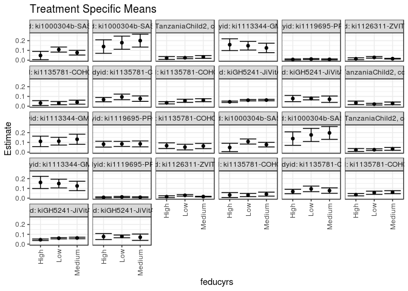

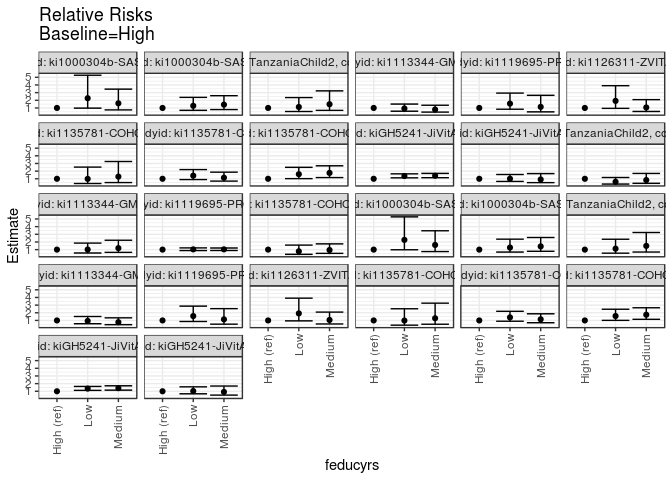

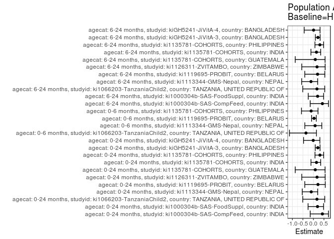

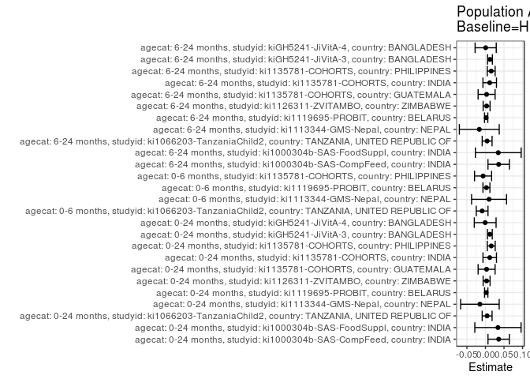

## Results Table

### Parameter: TSM

| agecat | studyid | country | intervention_level | baseline_level | estimate | ci_lower | ci_upper |
| --- | --- | --- | --- | --- | --- | --- | --- |
| 0-24 months | ki1000304b-SAS-CompFeed | INDIA | High | NA | 0.0479762 | 0.0053159 | 0.0906364 |
| 0-24 months | ki1000304b-SAS-CompFeed | INDIA | Low | NA | 0.1089371 | 0.0829270 | 0.1349472 |
| 0-24 months | ki1000304b-SAS-CompFeed | INDIA | Medium | NA | 0.0770914 | 0.0531683 | 0.1010145 |
| 0-24 months | ki1000304b-SAS-FoodSuppl | INDIA | High | NA | 0.1396539 | 0.0703901 | 0.2089178 |
| 0-24 months | ki1000304b-SAS-FoodSuppl | INDIA | Low | NA | 0.1789810 | 0.1116780 | 0.2462841 |
| 0-24 months | ki1000304b-SAS-FoodSuppl | INDIA | Medium | NA | 0.2001343 | 0.1344482 | 0.2658204 |
| 0-24 months | ki1066203-TanzaniaChild2 | TANZANIA, UNITED REPUBLIC OF | High | NA | 0.0223881 | 0.0079228 | 0.0368534 |
| 0-24 months | ki1066203-TanzaniaChild2 | TANZANIA, UNITED REPUBLIC OF | Low | NA | 0.0251736 | 0.0161255 | 0.0342217 |
| 0-24 months | ki1066203-TanzaniaChild2 | TANZANIA, UNITED REPUBLIC OF | Medium | NA | 0.0332779 | 0.0189349 | 0.0476209 |
| 0-24 months | ki1113344-GMS-Nepal | NEPAL | High | NA | 0.1587276 | 0.0984446 | 0.2190106 |
| 0-24 months | ki1113344-GMS-Nepal | NEPAL | Low | NA | 0.1479124 | 0.1040628 | 0.1917620 |
| 0-24 months | ki1113344-GMS-Nepal | NEPAL | Medium | NA | 0.1255860 | 0.0776127 | 0.1735594 |
| 0-24 months | ki1119695-PROBIT | BELARUS | High | NA | 0.0074367 | 0.0019326 | 0.0129407 |
| 0-24 months | ki1119695-PROBIT | BELARUS | Low | NA | 0.0116391 | 0.0063874 | 0.0168907 |
| 0-24 months | ki1119695-PROBIT | BELARUS | Medium | NA | 0.0084673 | 0.0032315 | 0.0137031 |
| 0-24 months | ki1126311-ZVITAMBO | ZIMBABWE | High | NA | 0.0148026 | 0.0052031 | 0.0244022 |
| 0-24 months | ki1126311-ZVITAMBO | ZIMBABWE | Low | NA | 0.0284450 | 0.0202527 | 0.0366373 |
| 0-24 months | ki1126311-ZVITAMBO | ZIMBABWE | Medium | NA | 0.0157297 | 0.0127864 | 0.0186730 |
| 0-24 months | ki1135781-COHORTS | GUATEMALA | High | NA | 0.0319149 | 0.0067764 | 0.0570534 |
| 0-24 months | ki1135781-COHORTS | GUATEMALA | Low | NA | 0.0314607 | 0.0152340 | 0.0476873 |
| 0-24 months | ki1135781-COHORTS | GUATEMALA | Medium | NA | 0.0409836 | 0.0206627 | 0.0613045 |
| 0-24 months | ki1135781-COHORTS | INDIA | High | NA | 0.0674170 | 0.0451646 | 0.0896695 |
| 0-24 months | ki1135781-COHORTS | INDIA | Low | NA | 0.0948704 | 0.0662156 | 0.1235253 |
| 0-24 months | ki1135781-COHORTS | INDIA | Medium | NA | 0.0768628 | 0.0488476 | 0.1048780 |
| 0-24 months | ki1135781-COHORTS | PHILIPPINES | High | NA | 0.0347056 | 0.0229309 | 0.0464803 |
| 0-24 months | ki1135781-COHORTS | PHILIPPINES | Low | NA | 0.0554230 | 0.0393271 | 0.0715188 |
| 0-24 months | ki1135781-COHORTS | PHILIPPINES | Medium | NA | 0.0613408 | 0.0459429 | 0.0767387 |
| 0-24 months | kiGH5241-JiVitA-3 | BANGLADESH | High | NA | 0.0448519 | 0.0373967 | 0.0523072 |
| 0-24 months | kiGH5241-JiVitA-3 | BANGLADESH | Low | NA | 0.0609932 | 0.0542463 | 0.0677401 |
| 0-24 months | kiGH5241-JiVitA-3 | BANGLADESH | Medium | NA | 0.0625556 | 0.0551373 | 0.0699739 |
| 0-24 months | kiGH5241-JiVitA-4 | BANGLADESH | High | NA | 0.0780996 | 0.0463749 | 0.1098243 |
| 0-24 months | kiGH5241-JiVitA-4 | BANGLADESH | Low | NA | 0.0788656 | 0.0649394 | 0.0927918 |
| 0-24 months | kiGH5241-JiVitA-4 | BANGLADESH | Medium | NA | 0.0711837 | 0.0384697 | 0.1038976 |
| 0-6 months | ki1066203-TanzaniaChild2 | TANZANIA, UNITED REPUBLIC OF | High | NA | 0.0343329 | 0.0162688 | 0.0523970 |
| 0-6 months | ki1066203-TanzaniaChild2 | TANZANIA, UNITED REPUBLIC OF | Low | NA | 0.0206528 | 0.0122487 | 0.0290569 |
| 0-6 months | ki1066203-TanzaniaChild2 | TANZANIA, UNITED REPUBLIC OF | Medium | NA | 0.0285223 | 0.0147521 | 0.0422925 |
| 0-6 months | ki1113344-GMS-Nepal | NEPAL | High | NA | 0.1104555 | 0.0570503 | 0.1638608 |
| 0-6 months | ki1113344-GMS-Nepal | NEPAL | Low | NA | 0.1121211 | 0.0724673 | 0.1517750 |
| 0-6 months | ki1113344-GMS-Nepal | NEPAL | Medium | NA | 0.1318605 | 0.0800544 | 0.1836665 |
| 0-6 months | ki1119695-PROBIT | BELARUS | High | NA | 0.0815474 | 0.0519469 | 0.1111479 |
| 0-6 months | ki1119695-PROBIT | BELARUS | Low | NA | 0.0842239 | 0.0585002 | 0.1099476 |
| 0-6 months | ki1119695-PROBIT | BELARUS | Medium | NA | 0.0843604 | 0.0542859 | 0.1144349 |
| 0-6 months | ki1135781-COHORTS | PHILIPPINES | High | NA | 0.0661614 | 0.0371508 | 0.0951720 |
| 0-6 months | ki1135781-COHORTS | PHILIPPINES | Low | NA | 0.0516419 | 0.0227084 | 0.0805754 |
| 0-6 months | ki1135781-COHORTS | PHILIPPINES | Medium | NA | 0.0626167 | 0.0356503 | 0.0895830 |
| 6-24 months | ki1000304b-SAS-CompFeed | INDIA | High | NA | 0.0479762 | 0.0053159 | 0.0906364 |
| 6-24 months | ki1000304b-SAS-CompFeed | INDIA | Low | NA | 0.1089371 | 0.0829270 | 0.1349472 |
| 6-24 months | ki1000304b-SAS-CompFeed | INDIA | Medium | NA | 0.0770914 | 0.0531683 | 0.1010145 |
| 6-24 months | ki1000304b-SAS-FoodSuppl | INDIA | High | NA | 0.1387886 | 0.0698553 | 0.2077218 |
| 6-24 months | ki1000304b-SAS-FoodSuppl | INDIA | Low | NA | 0.1760155 | 0.1088695 | 0.2431616 |
| 6-24 months | ki1000304b-SAS-FoodSuppl | INDIA | Medium | NA | 0.1967129 | 0.1308678 | 0.2625579 |
| 6-24 months | ki1066203-TanzaniaChild2 | TANZANIA, UNITED REPUBLIC OF | High | NA | 0.0223881 | 0.0079228 | 0.0368534 |
| 6-24 months | ki1066203-TanzaniaChild2 | TANZANIA, UNITED REPUBLIC OF | Low | NA | 0.0251736 | 0.0161255 | 0.0342217 |
| 6-24 months | ki1066203-TanzaniaChild2 | TANZANIA, UNITED REPUBLIC OF | Medium | NA | 0.0332779 | 0.0189349 | 0.0476209 |
| 6-24 months | ki1113344-GMS-Nepal | NEPAL | High | NA | 0.1604249 | 0.0983989 | 0.2224510 |
| 6-24 months | ki1113344-GMS-Nepal | NEPAL | Low | NA | 0.1489896 | 0.1043510 | 0.1936283 |
| 6-24 months | ki1113344-GMS-Nepal | NEPAL | Medium | NA | 0.1245431 | 0.0766725 | 0.1724137 |
| 6-24 months | ki1119695-PROBIT | BELARUS | High | NA | 0.0076172 | 0.0022157 | 0.0130186 |
| 6-24 months | ki1119695-PROBIT | BELARUS | Low | NA | 0.0119776 | 0.0067482 | 0.0172070 |
| 6-24 months | ki1119695-PROBIT | BELARUS | Medium | NA | 0.0086959 | 0.0035137 | 0.0138781 |
| 6-24 months | ki1126311-ZVITAMBO | ZIMBABWE | High | NA | 0.0148026 | 0.0052031 | 0.0244022 |
| 6-24 months | ki1126311-ZVITAMBO | ZIMBABWE | Low | NA | 0.0284450 | 0.0202527 | 0.0366373 |
| 6-24 months | ki1126311-ZVITAMBO | ZIMBABWE | Medium | NA | 0.0157297 | 0.0127864 | 0.0186730 |
| 6-24 months | ki1135781-COHORTS | GUATEMALA | High | NA | 0.0319149 | 0.0067764 | 0.0570534 |
| 6-24 months | ki1135781-COHORTS | GUATEMALA | Low | NA | 0.0314607 | 0.0152340 | 0.0476873 |
| 6-24 months | ki1135781-COHORTS | GUATEMALA | Medium | NA | 0.0409836 | 0.0206627 | 0.0613045 |
| 6-24 months | ki1135781-COHORTS | INDIA | High | NA | 0.0674384 | 0.0451069 | 0.0897700 |
| 6-24 months | ki1135781-COHORTS | INDIA | Low | NA | 0.0944955 | 0.0659649 | 0.1230262 |
| 6-24 months | ki1135781-COHORTS | INDIA | Medium | NA | 0.0772173 | 0.0494461 | 0.1049886 |
| 6-24 months | ki1135781-COHORTS | PHILIPPINES | High | NA | 0.0348632 | 0.0231421 | 0.0465843 |
| 6-24 months | ki1135781-COHORTS | PHILIPPINES | Low | NA | 0.0549777 | 0.0388330 | 0.0711225 |
| 6-24 months | ki1135781-COHORTS | PHILIPPINES | Medium | NA | 0.0608529 | 0.0455505 | 0.0761554 |
| 6-24 months | kiGH5241-JiVitA-3 | BANGLADESH | High | NA | 0.0445557 | 0.0371016 | 0.0520098 |
| 6-24 months | kiGH5241-JiVitA-3 | BANGLADESH | Low | NA | 0.0601238 | 0.0535080 | 0.0667397 |
| 6-24 months | kiGH5241-JiVitA-3 | BANGLADESH | Medium | NA | 0.0625563 | 0.0549584 | 0.0701542 |
| 6-24 months | kiGH5241-JiVitA-4 | BANGLADESH | High | NA | 0.0768019 | 0.0460847 | 0.1075190 |
| 6-24 months | kiGH5241-JiVitA-4 | BANGLADESH | Low | NA | 0.0788979 | 0.0649647 | 0.0928312 |
| 6-24 months | kiGH5241-JiVitA-4 | BANGLADESH | Medium | NA | 0.0703345 | 0.0378773 | 0.1027917 |

### Parameter: E(Y)

| agecat | studyid | country | intervention_level | baseline_level | estimate | ci_lower | ci_upper |
| --- | --- | --- | --- | --- | --- | --- | --- |
| 0-24 months | ki1000304b-SAS-CompFeed | INDIA | NA | NA | 0.0836390 | 0.0602327 | 0.1070453 |
| 0-24 months | ki1000304b-SAS-FoodSuppl | INDIA | NA | NA | 0.1733333 | 0.1349698 | 0.2116969 |
| 0-24 months | ki1066203-TanzaniaChild2 | TANZANIA, UNITED REPUBLIC OF | NA | NA | 0.0269142 | 0.0200799 | 0.0337484 |
| 0-24 months | ki1113344-GMS-Nepal | NEPAL | NA | NA | 0.1438240 | 0.1155088 | 0.1721392 |
| 0-24 months | ki1119695-PROBIT | BELARUS | NA | NA | 0.0094941 | 0.0051728 | 0.0138153 |
| 0-24 months | ki1126311-ZVITAMBO | ZIMBABWE | NA | NA | 0.0178887 | 0.0151586 | 0.0206188 |
| 0-24 months | ki1135781-COHORTS | GUATEMALA | NA | NA | 0.0350350 | 0.0236276 | 0.0464425 |
| 0-24 months | ki1135781-COHORTS | INDIA | NA | NA | 0.0789050 | 0.0639058 | 0.0939041 |
| 0-24 months | ki1135781-COHORTS | PHILIPPINES | NA | NA | 0.0503949 | 0.0420785 | 0.0587113 |
| 0-24 months | kiGH5241-JiVitA-3 | BANGLADESH | NA | NA | 0.0567315 | 0.0525489 | 0.0609140 |
| 0-24 months | kiGH5241-JiVitA-4 | BANGLADESH | NA | NA | 0.0773869 | 0.0653840 | 0.0893899 |
| 0-6 months | ki1066203-TanzaniaChild2 | TANZANIA, UNITED REPUBLIC OF | NA | NA | 0.0253535 | 0.0185487 | 0.0321583 |
| 0-6 months | ki1113344-GMS-Nepal | NEPAL | NA | NA | 0.1201479 | 0.0927249 | 0.1475708 |
| 0-6 months | ki1119695-PROBIT | BELARUS | NA | NA | 0.0841807 | 0.0567141 | 0.1116474 |
| 0-6 months | ki1135781-COHORTS | PHILIPPINES | NA | NA | 0.0597015 | 0.0433139 | 0.0760891 |
| 6-24 months | ki1000304b-SAS-CompFeed | INDIA | NA | NA | 0.0836390 | 0.0602327 | 0.1070453 |
| 6-24 months | ki1000304b-SAS-FoodSuppl | INDIA | NA | NA | 0.1733333 | 0.1349698 | 0.2116969 |
| 6-24 months | ki1066203-TanzaniaChild2 | TANZANIA, UNITED REPUBLIC OF | NA | NA | 0.0269142 | 0.0200799 | 0.0337484 |
| 6-24 months | ki1113344-GMS-Nepal | NEPAL | NA | NA | 0.1438240 | 0.1155088 | 0.1721392 |
| 6-24 months | ki1119695-PROBIT | BELARUS | NA | NA | 0.0094941 | 0.0051728 | 0.0138153 |
| 6-24 months | ki1126311-ZVITAMBO | ZIMBABWE | NA | NA | 0.0178887 | 0.0151586 | 0.0206188 |
| 6-24 months | ki1135781-COHORTS | GUATEMALA | NA | NA | 0.0350350 | 0.0236276 | 0.0464425 |
| 6-24 months | ki1135781-COHORTS | INDIA | NA | NA | 0.0789050 | 0.0639058 | 0.0939041 |
| 6-24 months | ki1135781-COHORTS | PHILIPPINES | NA | NA | 0.0503949 | 0.0420785 | 0.0587113 |
| 6-24 months | kiGH5241-JiVitA-3 | BANGLADESH | NA | NA | 0.0567315 | 0.0525489 | 0.0609140 |
| 6-24 months | kiGH5241-JiVitA-4 | BANGLADESH | NA | NA | 0.0773869 | 0.0653840 | 0.0893899 |

### Parameter: RR

| agecat | studyid | country | intervention_level | baseline_level | estimate | ci_lower | ci_upper |
| --- | --- | --- | --- | --- | --- | --- | --- |
| 0-24 months | ki1000304b-SAS-CompFeed | INDIA | High | High | 1.0000000 | 1.0000000 | 1.000000 |
| 0-24 months | ki1000304b-SAS-CompFeed | INDIA | Low | High | 2.2706501 | 0.9774568 | 5.274762 |
| 0-24 months | ki1000304b-SAS-CompFeed | INDIA | Medium | High | 1.6068688 | 0.7466768 | 3.458025 |
| 0-24 months | ki1000304b-SAS-FoodSuppl | INDIA | High | High | 1.0000000 | 1.0000000 | 1.000000 |
| 0-24 months | ki1000304b-SAS-FoodSuppl | INDIA | Low | High | 1.2816040 | 0.6897232 | 2.381403 |
| 0-24 months | ki1000304b-SAS-FoodSuppl | INDIA | Medium | High | 1.4330733 | 0.7897386 | 2.600479 |
| 0-24 months | ki1066203-TanzaniaChild2 | TANZANIA, UNITED REPUBLIC OF | High | High | 1.0000000 | 1.0000000 | 1.000000 |
| 0-24 months | ki1066203-TanzaniaChild2 | TANZANIA, UNITED REPUBLIC OF | Low | High | 1.1244213 | 0.5368195 | 2.355211 |
| 0-24 months | ki1066203-TanzaniaChild2 | TANZANIA, UNITED REPUBLIC OF | Medium | High | 1.4864115 | 0.6836450 | 3.231822 |
| 0-24 months | ki1113344-GMS-Nepal | NEPAL | High | High | 1.0000000 | 1.0000000 | 1.000000 |
| 0-24 months | ki1113344-GMS-Nepal | NEPAL | Low | High | 0.9318631 | 0.5756448 | 1.508515 |
| 0-24 months | ki1113344-GMS-Nepal | NEPAL | Medium | High | 0.7912048 | 0.4615962 | 1.356174 |
| 0-24 months | ki1119695-PROBIT | BELARUS | High | High | 1.0000000 | 1.0000000 | 1.000000 |
| 0-24 months | ki1119695-PROBIT | BELARUS | Low | High | 1.5650904 | 0.8338879 | 2.937455 |
| 0-24 months | ki1119695-PROBIT | BELARUS | Medium | High | 1.1385880 | 0.4899043 | 2.646196 |
| 0-24 months | ki1126311-ZVITAMBO | ZIMBABWE | High | High | 1.0000000 | 1.0000000 | 1.000000 |
| 0-24 months | ki1126311-ZVITAMBO | ZIMBABWE | Low | High | 1.9216182 | 0.9451494 | 3.906913 |
| 0-24 months | ki1126311-ZVITAMBO | ZIMBABWE | Medium | High | 1.0626274 | 0.5410654 | 2.086951 |
| 0-24 months | ki1135781-COHORTS | GUATEMALA | High | High | 1.0000000 | 1.0000000 | 1.000000 |
| 0-24 months | ki1135781-COHORTS | GUATEMALA | Low | High | 0.9857678 | 0.3844846 | 2.527379 |
| 0-24 months | ki1135781-COHORTS | GUATEMALA | Medium | High | 1.2841530 | 0.5062921 | 3.257110 |
| 0-24 months | ki1135781-COHORTS | INDIA | High | High | 1.0000000 | 1.0000000 | 1.000000 |
| 0-24 months | ki1135781-COHORTS | INDIA | Low | High | 1.4072181 | 0.8994939 | 2.201530 |
| 0-24 months | ki1135781-COHORTS | INDIA | Medium | High | 1.1401096 | 0.6974194 | 1.863800 |
| 0-24 months | ki1135781-COHORTS | PHILIPPINES | High | High | 1.0000000 | 1.0000000 | 1.000000 |
| 0-24 months | ki1135781-COHORTS | PHILIPPINES | Low | High | 1.5969455 | 1.0217977 | 2.495832 |
| 0-24 months | ki1135781-COHORTS | PHILIPPINES | Medium | High | 1.7674606 | 1.1589650 | 2.695437 |
| 0-24 months | kiGH5241-JiVitA-3 | BANGLADESH | High | High | 1.0000000 | 1.0000000 | 1.000000 |
| 0-24 months | kiGH5241-JiVitA-3 | BANGLADESH | Low | High | 1.3598791 | 1.1251824 | 1.643530 |
| 0-24 months | kiGH5241-JiVitA-3 | BANGLADESH | Medium | High | 1.3947143 | 1.1431356 | 1.701660 |
| 0-24 months | kiGH5241-JiVitA-4 | BANGLADESH | High | High | 1.0000000 | 1.0000000 | 1.000000 |
| 0-24 months | kiGH5241-JiVitA-4 | BANGLADESH | Low | High | 1.0098077 | 0.6538164 | 1.559630 |
| 0-24 months | kiGH5241-JiVitA-4 | BANGLADESH | Medium | High | 0.9114470 | 0.4953776 | 1.676975 |
| 0-6 months | ki1066203-TanzaniaChild2 | TANZANIA, UNITED REPUBLIC OF | High | High | 1.0000000 | 1.0000000 | 1.000000 |
| 0-6 months | ki1066203-TanzaniaChild2 | TANZANIA, UNITED REPUBLIC OF | Low | High | 0.6015457 | 0.3093189 | 1.169851 |
| 0-6 months | ki1066203-TanzaniaChild2 | TANZANIA, UNITED REPUBLIC OF | Medium | High | 0.8307576 | 0.4067756 | 1.696656 |
| 0-6 months | ki1113344-GMS-Nepal | NEPAL | High | High | 1.0000000 | 1.0000000 | 1.000000 |
| 0-6 months | ki1113344-GMS-Nepal | NEPAL | Low | High | 1.0150793 | 0.5570068 | 1.849863 |
| 0-6 months | ki1113344-GMS-Nepal | NEPAL | Medium | High | 1.1937880 | 0.6402015 | 2.226064 |
| 0-6 months | ki1119695-PROBIT | BELARUS | High | High | 1.0000000 | 1.0000000 | 1.000000 |
| 0-6 months | ki1119695-PROBIT | BELARUS | Low | High | 1.0328211 | 0.8728761 | 1.222074 |
| 0-6 months | ki1119695-PROBIT | BELARUS | Medium | High | 1.0344954 | 0.8848003 | 1.209517 |
| 0-6 months | ki1135781-COHORTS | PHILIPPINES | High | High | 1.0000000 | 1.0000000 | 1.000000 |
| 0-6 months | ki1135781-COHORTS | PHILIPPINES | Low | High | 0.7805447 | 0.3830895 | 1.590360 |
| 0-6 months | ki1135781-COHORTS | PHILIPPINES | Medium | High | 0.9464227 | 0.5116388 | 1.750680 |
| 6-24 months | ki1000304b-SAS-CompFeed | INDIA | High | High | 1.0000000 | 1.0000000 | 1.000000 |
| 6-24 months | ki1000304b-SAS-CompFeed | INDIA | Low | High | 2.2706501 | 0.9774568 | 5.274762 |
| 6-24 months | ki1000304b-SAS-CompFeed | INDIA | Medium | High | 1.6068688 | 0.7466768 | 3.458025 |
| 6-24 months | ki1000304b-SAS-FoodSuppl | INDIA | High | High | 1.0000000 | 1.0000000 | 1.000000 |
| 6-24 months | ki1000304b-SAS-FoodSuppl | INDIA | Low | High | 1.2682276 | 0.6804356 | 2.363782 |
| 6-24 months | ki1000304b-SAS-FoodSuppl | INDIA | Medium | High | 1.4173562 | 0.7789184 | 2.579087 |
| 6-24 months | ki1066203-TanzaniaChild2 | TANZANIA, UNITED REPUBLIC OF | High | High | 1.0000000 | 1.0000000 | 1.000000 |
| 6-24 months | ki1066203-TanzaniaChild2 | TANZANIA, UNITED REPUBLIC OF | Low | High | 1.1244213 | 0.5368195 | 2.355211 |
| 6-24 months | ki1066203-TanzaniaChild2 | TANZANIA, UNITED REPUBLIC OF | Medium | High | 1.4864115 | 0.6836450 | 3.231822 |
| 6-24 months | ki1113344-GMS-Nepal | NEPAL | High | High | 1.0000000 | 1.0000000 | 1.000000 |
| 6-24 months | ki1113344-GMS-Nepal | NEPAL | Low | High | 0.9287189 | 0.5694219 | 1.514727 |
| 6-24 months | ki1113344-GMS-Nepal | NEPAL | Medium | High | 0.7763328 | 0.4499032 | 1.339605 |
| 6-24 months | ki1119695-PROBIT | BELARUS | High | High | 1.0000000 | 1.0000000 | 1.000000 |
| 6-24 months | ki1119695-PROBIT | BELARUS | Low | High | 1.5724400 | 0.8623585 | 2.867215 |
| 6-24 months | ki1119695-PROBIT | BELARUS | Medium | High | 1.1416151 | 0.5122746 | 2.544114 |
| 6-24 months | ki1126311-ZVITAMBO | ZIMBABWE | High | High | 1.0000000 | 1.0000000 | 1.000000 |
| 6-24 months | ki1126311-ZVITAMBO | ZIMBABWE | Low | High | 1.9216182 | 0.9451494 | 3.906913 |
| 6-24 months | ki1126311-ZVITAMBO | ZIMBABWE | Medium | High | 1.0626274 | 0.5410654 | 2.086951 |
| 6-24 months | ki1135781-COHORTS | GUATEMALA | High | High | 1.0000000 | 1.0000000 | 1.000000 |
| 6-24 months | ki1135781-COHORTS | GUATEMALA | Low | High | 0.9857678 | 0.3844846 | 2.527379 |
| 6-24 months | ki1135781-COHORTS | GUATEMALA | Medium | High | 1.2841530 | 0.5062921 | 3.257110 |
| 6-24 months | ki1135781-COHORTS | INDIA | High | High | 1.0000000 | 1.0000000 | 1.000000 |
| 6-24 months | ki1135781-COHORTS | INDIA | Low | High | 1.4012122 | 0.8949368 | 2.193893 |
| 6-24 months | ki1135781-COHORTS | INDIA | Medium | High | 1.1450048 | 0.7022913 | 1.866798 |
| 6-24 months | ki1135781-COHORTS | PHILIPPINES | High | High | 1.0000000 | 1.0000000 | 1.000000 |
| 6-24 months | ki1135781-COHORTS | PHILIPPINES | Low | High | 1.5769562 | 1.0090149 | 2.464573 |
| 6-24 months | ki1135781-COHORTS | PHILIPPINES | Medium | High | 1.7454776 | 1.1468794 | 2.656506 |
| 6-24 months | kiGH5241-JiVitA-3 | BANGLADESH | High | High | 1.0000000 | 1.0000000 | 1.000000 |
| 6-24 months | kiGH5241-JiVitA-3 | BANGLADESH | Low | High | 1.3494069 | 1.1167486 | 1.630536 |
| 6-24 months | kiGH5241-JiVitA-3 | BANGLADESH | Medium | High | 1.4040010 | 1.1485732 | 1.716233 |
| 6-24 months | kiGH5241-JiVitA-4 | BANGLADESH | High | High | 1.0000000 | 1.0000000 | 1.000000 |
| 6-24 months | kiGH5241-JiVitA-4 | BANGLADESH | Low | High | 1.0272920 | 0.6691876 | 1.577030 |
| 6-24 months | kiGH5241-JiVitA-4 | BANGLADESH | Medium | High | 0.9157917 | 0.4981417 | 1.683606 |

### Parameter: PAR

| agecat | studyid | country | intervention_level | baseline_level | estimate | ci_lower | ci_upper |
| --- | --- | --- | --- | --- | --- | --- | --- |
| 0-24 months | ki1000304b-SAS-CompFeed | INDIA | High | NA | 0.0356629 | 0.0068211 | 0.0645046 |
| 0-24 months | ki1000304b-SAS-FoodSuppl | INDIA | High | NA | 0.0336794 | -0.0286591 | 0.0960179 |
| 0-24 months | ki1066203-TanzaniaChild2 | TANZANIA, UNITED REPUBLIC OF | High | NA | 0.0045261 | -0.0088113 | 0.0178635 |
| 0-24 months | ki1113344-GMS-Nepal | NEPAL | High | NA | -0.0149036 | -0.0668553 | 0.0370481 |
| 0-24 months | ki1119695-PROBIT | BELARUS | High | NA | 0.0020574 | -0.0024202 | 0.0065350 |
| 0-24 months | ki1126311-ZVITAMBO | ZIMBABWE | High | NA | 0.0030861 | -0.0062537 | 0.0124258 |
| 0-24 months | ki1135781-COHORTS | GUATEMALA | High | NA | 0.0031201 | -0.0197759 | 0.0260162 |
| 0-24 months | ki1135781-COHORTS | INDIA | High | NA | 0.0114880 | -0.0066961 | 0.0296720 |
| 0-24 months | ki1135781-COHORTS | PHILIPPINES | High | NA | 0.0156893 | 0.0050660 | 0.0263125 |
| 0-24 months | kiGH5241-JiVitA-3 | BANGLADESH | High | NA | 0.0118796 | 0.0054407 | 0.0183184 |
| 0-24 months | kiGH5241-JiVitA-4 | BANGLADESH | High | NA | -0.0007127 | -0.0301000 | 0.0286747 |
| 0-6 months | ki1066203-TanzaniaChild2 | TANZANIA, UNITED REPUBLIC OF | High | NA | -0.0089794 | -0.0248097 | 0.0068509 |
| 0-6 months | ki1113344-GMS-Nepal | NEPAL | High | NA | 0.0096924 | -0.0374201 | 0.0568048 |
| 0-6 months | ki1119695-PROBIT | BELARUS | High | NA | 0.0026334 | -0.0067333 | 0.0120000 |
| 0-6 months | ki1135781-COHORTS | PHILIPPINES | High | NA | -0.0064599 | -0.0294877 | 0.0165679 |
| 6-24 months | ki1000304b-SAS-CompFeed | INDIA | High | NA | 0.0356629 | 0.0068211 | 0.0645046 |
| 6-24 months | ki1000304b-SAS-FoodSuppl | INDIA | High | NA | 0.0345448 | -0.0271638 | 0.0962533 |
| 6-24 months | ki1066203-TanzaniaChild2 | TANZANIA, UNITED REPUBLIC OF | High | NA | 0.0045261 | -0.0088113 | 0.0178635 |
| 6-24 months | ki1113344-GMS-Nepal | NEPAL | High | NA | -0.0166009 | -0.0703395 | 0.0371378 |
| 6-24 months | ki1119695-PROBIT | BELARUS | High | NA | 0.0018769 | -0.0025384 | 0.0062921 |
| 6-24 months | ki1126311-ZVITAMBO | ZIMBABWE | High | NA | 0.0030861 | -0.0062537 | 0.0124258 |
| 6-24 months | ki1135781-COHORTS | GUATEMALA | High | NA | 0.0031201 | -0.0197759 | 0.0260162 |
| 6-24 months | ki1135781-COHORTS | INDIA | High | NA | 0.0114666 | -0.0067890 | 0.0297222 |
| 6-24 months | ki1135781-COHORTS | PHILIPPINES | High | NA | 0.0155317 | 0.0049500 | 0.0261133 |
| 6-24 months | kiGH5241-JiVitA-3 | BANGLADESH | High | NA | 0.0121757 | 0.0057387 | 0.0186128 |
| 6-24 months | kiGH5241-JiVitA-4 | BANGLADESH | High | NA | 0.0005851 | -0.0279429 | 0.0291131 |

### Parameter: PAF

| agecat | studyid | country | intervention_level | baseline_level | estimate | ci_lower | ci_upper |
| --- | --- | --- | --- | --- | --- | --- | --- |
| 0-24 months | ki1000304b-SAS-CompFeed | INDIA | High | NA | 0.4263903 | -0.1519905 | 0.7143830 |
| 0-24 months | ki1000304b-SAS-FoodSuppl | INDIA | High | NA | 0.1943043 | -0.2551516 | 0.4828150 |
| 0-24 months | ki1066203-TanzaniaChild2 | TANZANIA, UNITED REPUBLIC OF | High | NA | 0.1681678 | -0.5060612 | 0.5405599 |
| 0-24 months | ki1113344-GMS-Nepal | NEPAL | High | NA | -0.1036236 | -0.5304843 | 0.2041833 |
| 0-24 months | ki1119695-PROBIT | BELARUS | High | NA | 0.2167033 | -0.4097614 | 0.5647819 |
| 0-24 months | ki1126311-ZVITAMBO | ZIMBABWE | High | NA | 0.1725146 | -0.5539660 | 0.5593648 |
| 0-24 months | ki1135781-COHORTS | GUATEMALA | High | NA | 0.0890578 | -0.8653949 | 0.5551528 |
| 0-24 months | ki1135781-COHORTS | INDIA | High | NA | 0.1455925 | -0.1170904 | 0.3465057 |
| 0-24 months | ki1135781-COHORTS | PHILIPPINES | High | NA | 0.3113266 | 0.0734215 | 0.4881481 |
| 0-24 months | kiGH5241-JiVitA-3 | BANGLADESH | High | NA | 0.2093999 | 0.0872559 | 0.3151985 |
| 0-24 months | kiGH5241-JiVitA-4 | BANGLADESH | High | NA | -0.0092092 | -0.4702798 | 0.3072725 |
| 0-6 months | ki1066203-TanzaniaChild2 | TANZANIA, UNITED REPUBLIC OF | High | NA | -0.3541684 | -1.1383042 | 0.1424175 |
| 0-6 months | ki1113344-GMS-Nepal | NEPAL | High | NA | 0.0806703 | -0.4077067 | 0.3996142 |
| 0-6 months | ki1119695-PROBIT | BELARUS | High | NA | 0.0312823 | -0.0879053 | 0.1374121 |
| 0-6 months | ki1135781-COHORTS | PHILIPPINES | High | NA | -0.1082035 | -0.5687950 | 0.2171603 |
| 6-24 months | ki1000304b-SAS-CompFeed | INDIA | High | NA | 0.4263903 | -0.1519905 | 0.7143830 |
| 6-24 months | ki1000304b-SAS-FoodSuppl | INDIA | High | NA | 0.1992967 | -0.2456030 | 0.4852888 |
| 6-24 months | ki1066203-TanzaniaChild2 | TANZANIA, UNITED REPUBLIC OF | High | NA | 0.1681678 | -0.5060612 | 0.5405599 |
| 6-24 months | ki1113344-GMS-Nepal | NEPAL | High | NA | -0.1154250 | -0.5585818 | 0.2017276 |
| 6-24 months | ki1119695-PROBIT | BELARUS | High | NA | 0.1976888 | -0.4100045 | 0.5434743 |
| 6-24 months | ki1126311-ZVITAMBO | ZIMBABWE | High | NA | 0.1725146 | -0.5539660 | 0.5593648 |
| 6-24 months | ki1135781-COHORTS | GUATEMALA | High | NA | 0.0890578 | -0.8653949 | 0.5551528 |
| 6-24 months | ki1135781-COHORTS | INDIA | High | NA | 0.1453212 | -0.1186038 | 0.3469754 |
| 6-24 months | ki1135781-COHORTS | PHILIPPINES | High | NA | 0.3081996 | 0.0717541 | 0.4844170 |
| 6-24 months | kiGH5241-JiVitA-3 | BANGLADESH | High | NA | 0.2146207 | 0.0924177 | 0.3203695 |
| 6-24 months | kiGH5241-JiVitA-4 | BANGLADESH | High | NA | 0.0075604 | -0.4388406 | 0.3154653 |